# df_2

Autogenerated data summary from dataMaid

2023-04-07 22:20:24

# Data report overview

The dataset examined has the following dimensions:

| Feature | Result |
| --- | --- |
| Number of observations | 2938 |
| Number of variables | 22 |

### Checks performed

The following variable checks were performed, depending on the data type of each variable:

|  | character | factor | labelled | haven labelled | numeric | integer | logical | Date |
| --- | --- | --- | --- | --- | --- | --- | --- | --- |
| Identify miscoded missing values | × | × | × | × | × | × |  | × |
| Identify prefixed and suffixed whitespace | × | × | × | × |  |  |  |  |
| Identify levels with < 6 obs. | × | × | × | × |  |  |  |  |
| Identify case issues | × | × | × | × |  |  |  |  |
| Identify misclassified numeric or integer variables | × | × | × | × |  |  |  |  |
| Identify outliers |  |  |  |  | × | × |  | × |

Please note that all numerical values in the following have been rounded to 2 decimals.

# Summary table

|  | Variable class | # unique values | Missing observations | Any problems? |
| --- | --- | --- | --- | --- |
| Country | character | 193 | 0.00 % | × |
| Year | numeric | 16 | 0.00 % |  |
| Status | character | 2 | 0.00 % |  |
| Life expectancy | numeric | 363 | 0.34 % | × |
| Adult Mortality | numeric | 426 | 0.34 % | × |
| infant deaths | numeric | 209 | 0.00 % | × |
| Alcohol | numeric | 1077 | 6.60 % |  |
| percentage expenditure | numeric | 2328 | 0.00 % | × |
| HepatitisB | numeric | 88 | 18.82 % |  |
| Measles | numeric | 958 | 0.00 % | × |
| BMI | numeric | 609 | 1.16 % | × |
| underfive_deaths | numeric | 252 | 0.00 % | × |
| Polio | numeric | 74 | 0.65 % |  |
| Total expenditure | numeric | 819 | 7.69 % | × |
| Diphtheria | numeric | 82 | 0.65 % |  |
| HIV_AIDS | numeric | 200 | 0.00 % | × |
| GDP | numeric | 2491 | 15.25 % | × |
| Population | numeric | 2279 | 22.19 % | × |
| thinness _1to19years | numeric | 201 | 1.16 % |  |
| thinness_5to9_years | numeric | 208 | 1.16 % |  |
| Income composition of resources | numeric | 626 | 5.68 % | × |
| Schooling | numeric | 174 | 5.55 % | × |

# Variable list

## Country

| Feature | Result |
| --- | --- |
| Variable type | character |
| Number of missing obs. | 0 (0 %) |
| Number of unique values | 193 |
| Mode | “Afghanistan” |

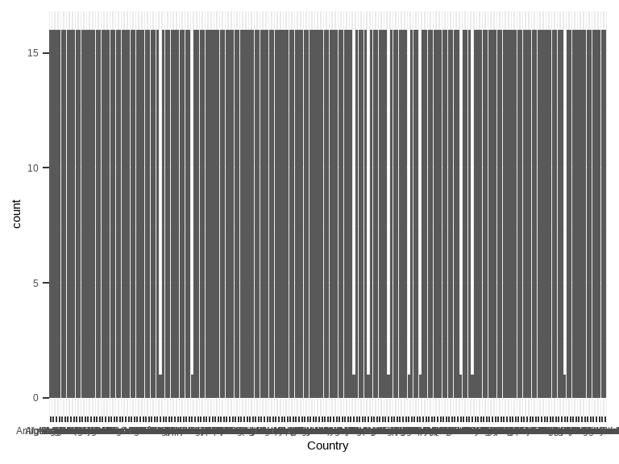

- Note that the following levels have at most five observations: "Cook Islands", "Dominica", "Marshall Islands", "Monaco", "Nauru", "Niue", "Palau", "Saint Kitts and Nevis", "San Marino", "Tuvalu".

## Year

| Feature | Result |
| --- | --- |
| Variable type | numeric |
| Number of missing obs. | 0 (0 %) |
| Number of unique values | 16 |
| Median | 2008 |
| 1st and 3rd quartiles | 2004; 2012 |
| Min. and max. | 2000; 2015 |

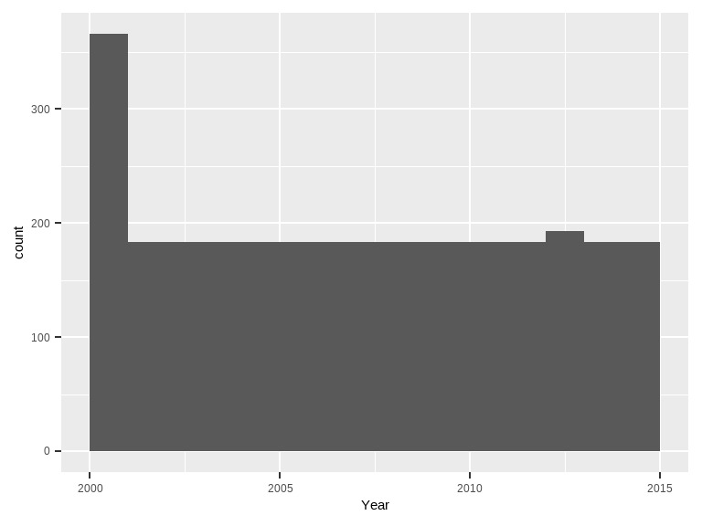

## Status

| Feature | Result |
| --- | --- |
| Variable type | character |
| Number of missing obs. | 0 (0 %) |
| Number of unique values | 2 |
| Mode | “Developing” |

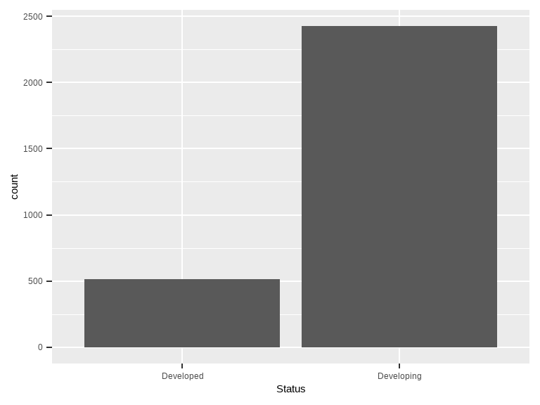

## Life expectancy

| Feature | Result |
| --- | --- |
| Variable type | numeric |
| Number of missing obs. | 10 (0.34 %) |
| Number of unique values | 362 |
| Median | 72.1 |
| 1st and 3rd quartiles | 63.1; 75.7 |
| Min. and max. | 36.3; 89 |

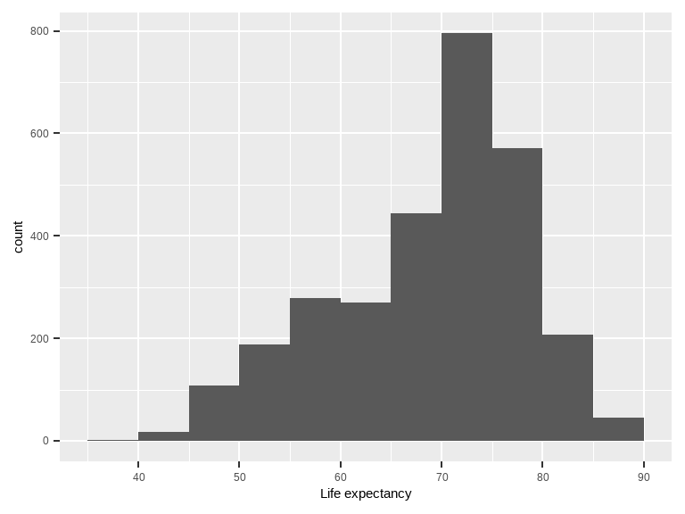

- Note that the following possible outlier values were detected: "79.6", "79.7", "79.8", "79.9", "80", …, "85", "86", "87", "88", "89" (28 values omitted).

## Adult Mortality

| Feature | Result |
| --- | --- |
| Variable type | numeric |
| Number of missing obs. | 10 (0.34 %) |
| Number of unique values | 425 |
| Median | 144 |
| 1st and 3rd quartiles | 74; 228 |
| Min. and max. | 1; 723 |

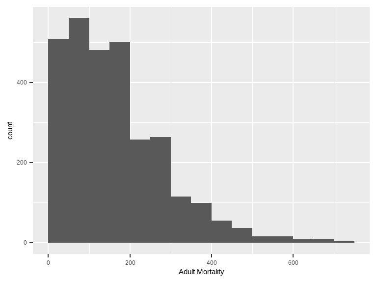

- Note that the following possible outlier values were detected: "592", "593", "599", "611", "613", …, "693", "699", "715", "717", "723" (15 values omitted).

## infant deaths

| Feature | Result |
| --- | --- |
| Variable type | numeric |
| Number of missing obs. | 0 (0 %) |
| Number of unique values | 209 |
| Median | 3 |
| 1st and 3rd quartiles | 0; 22 |
| Min. and max. | 0; 1800 |

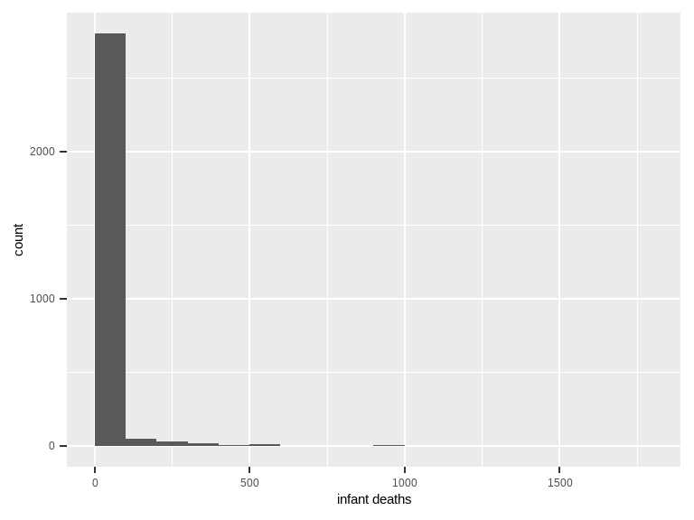

- Note that the following possible outlier values were detected: "385", "391", "422", "457", "483", …, "1400", "1500", "1600", "1700", "1800" (21 values omitted).

## Alcohol

| Feature | Result |
| --- | --- |
| Variable type | numeric |
| Number of missing obs. | 194 (6.6 %) |
| Number of unique values | 1076 |
| Median | 3.76 |
| 1st and 3rd quartiles | 0.88; 7.7 |
| Min. and max. | 0.01; 17.87 |

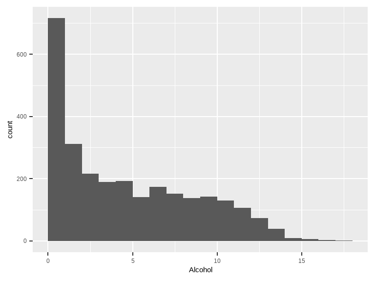

## percentage expenditure

| Feature | Result |
| --- | --- |
| Variable type | numeric |
| Number of missing obs. | 0 (0 %) |
| Number of unique values | 2328 |
| Median | 64.91 |
| 1st and 3rd quartiles | 4.69; 441.53 |
| Min. and max. | 0; 19479.91 |

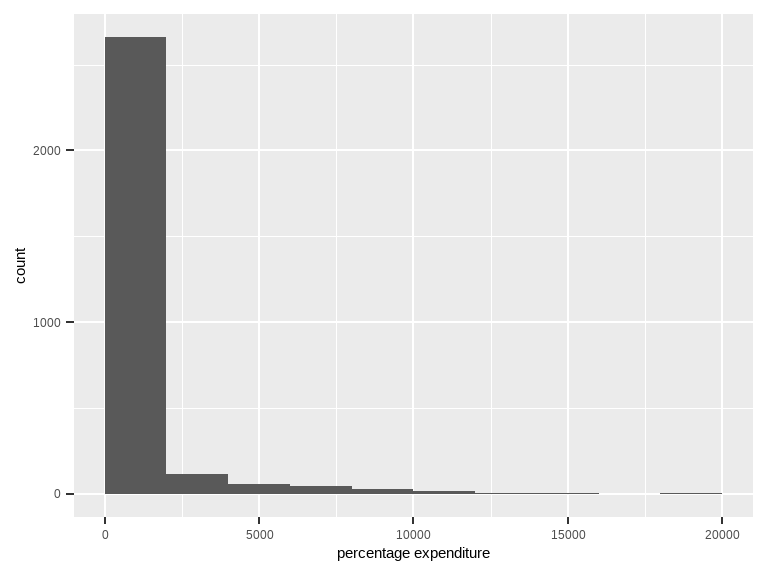

- Note that the following possible outlier values were detected: "7313.18", "7423.23", "7453.86", "7584.08", "7593.39", …, "18379.33", "18822.87", "18961.35", "19099.05", "19479.91" (63 values omitted).

## HepatitisB

| Feature | Result |
| --- | --- |
| Variable type | numeric |
| Number of missing obs. | 553 (18.82 %) |
| Number of unique values | 87 |
| Median | 92 |
| 1st and 3rd quartiles | 77; 97 |
| Min. and max. | 1; 99 |

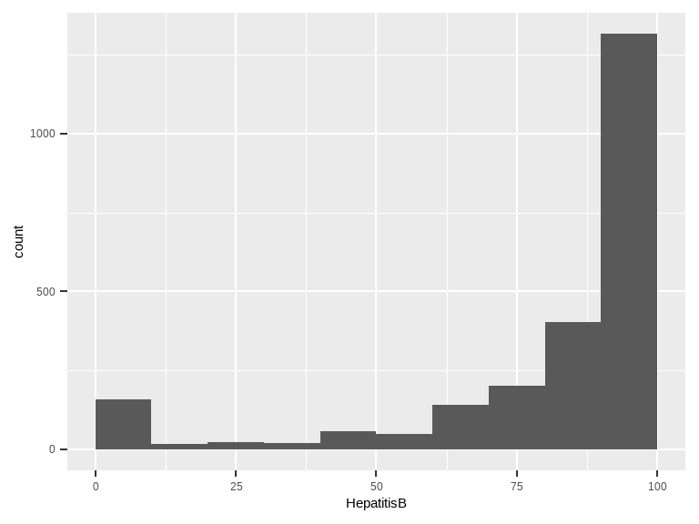

## Measles

| Feature | Result |
| --- | --- |
| Variable type | numeric |
| Number of missing obs. | 0 (0 %) |
| Number of unique values | 958 |
| Median | 17 |
| 1st and 3rd quartiles | 0; 360.25 |
| Min. and max. | 0; 212183 |

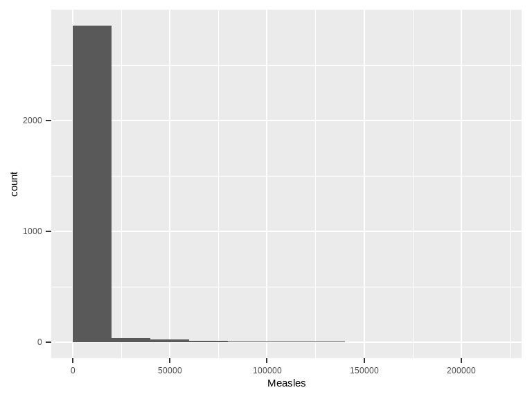

- Note that the following possible outlier values were detected: "9046", "9081", "9357", "9385", "9396", …, "133802", "141258", "168107", "182485", "212183" (152 values omitted).

## BMI

| Feature | Result |
| --- | --- |
| Variable type | numeric |
| Number of missing obs. | 34 (1.16 %) |
| Number of unique values | 608 |
| Median | 43.5 |
| 1st and 3rd quartiles | 19.3; 56.2 |
| Min. and max. | 1; 87.3 |

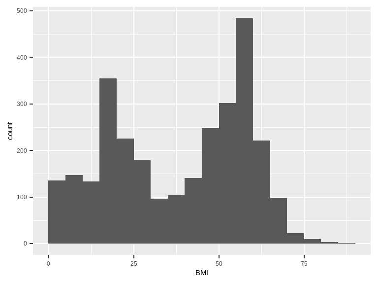

- Note that the following possible outlier values were detected: "73.3", "73.4", "73.8", "74.1", "74.3", …, "79.3", "81.6", "82.8", "83.3", "87.3" (10 values omitted).

## underfive_deaths

| Feature | Result |
| --- | --- |
| Variable type | numeric |
| Number of missing obs. | 0 (0 %) |
| Number of unique values | 252 |
| Median | 4 |
| 1st and 3rd quartiles | 0; 28 |
| Min. and max. | 0; 2500 |

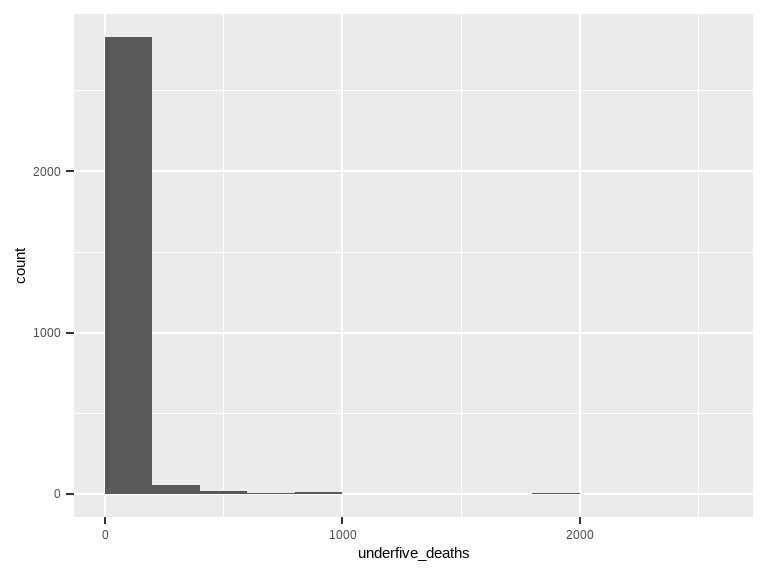

- Note that the following possible outlier values were detected: "511", "558", "608", "747", "759", …, "2100", "2200", "2300", "2400", "2500" (24 values omitted).

## Polio

| Feature | Result |
| --- | --- |
| Variable type | numeric |
| Number of missing obs. | 19 (0.65 %) |
| Number of unique values | 73 |
| Median | 93 |
| 1st and 3rd quartiles | 78; 97 |
| Min. and max. | 3; 99 |

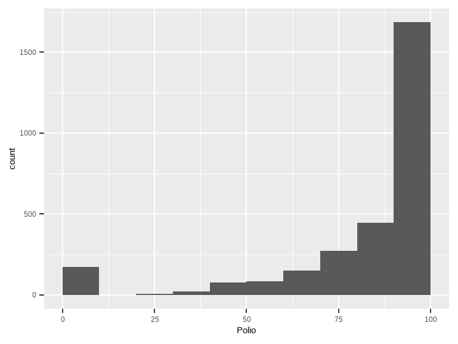

## Total expenditure

| Feature | Result |
| --- | --- |
| Variable type | numeric |
| Number of missing obs. | 226 (7.69 %) |
| Number of unique values | 818 |
| Median | 5.76 |
| 1st and 3rd quartiles | 4.26; 7.49 |
| Min. and max. | 0.37; 17.6 |

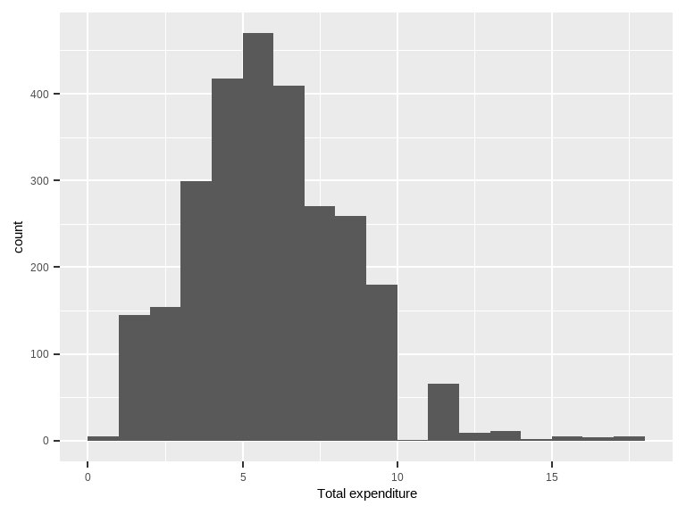

- Note that the following possible outlier values were detected: "0.37", "13.44", "13.63", "13.66", "13.7", …, "17", "17.14", "17.2", "17.24", "17.6" (14 values omitted).

## Diphtheria

| Feature | Result |
| --- | --- |
| Variable type | numeric |
| Number of missing obs. | 19 (0.65 %) |
| Number of unique values | 81 |
| Median | 93 |
| 1st and 3rd quartiles | 78; 97 |
| Min. and max. | 2; 99 |

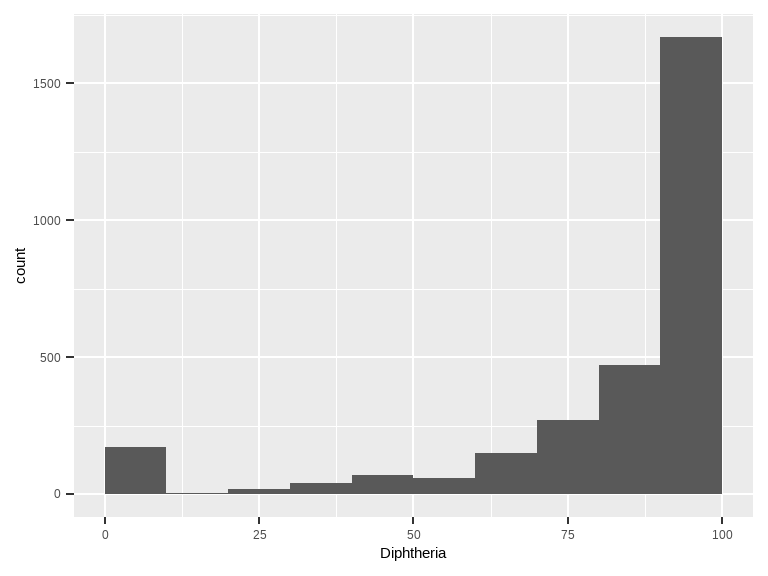

## HIV_AIDS

| Feature | Result |
| --- | --- |
| Variable type | numeric |
| Number of missing obs. | 0 (0 %) |
| Number of unique values | 200 |
| Median | 0.1 |
| 1st and 3rd quartiles | 0.1; 0.8 |
| Min. and max. | 0.1; 50.6 |

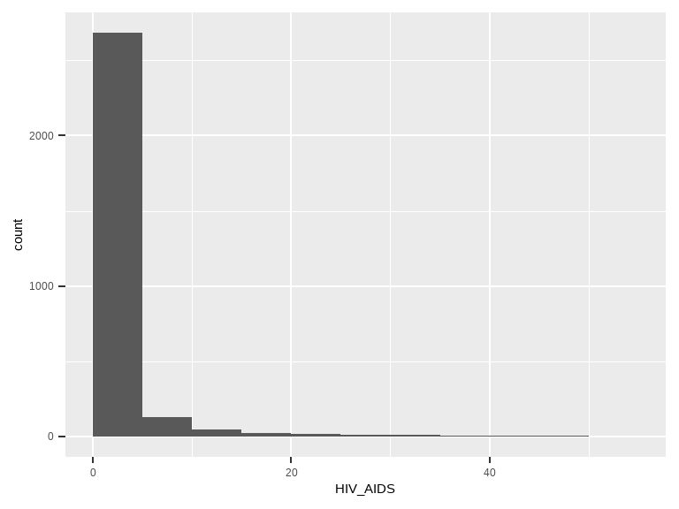

- Note that the following possible outlier values were detected: "22.1", "22.4", "22.8", "23.4", "23.5", …, "48.8", "49.1", "49.9", "50.3", "50.6" (39 values omitted).

## GDP

| Feature | Result |
| --- | --- |
| Variable type | numeric |
| Number of missing obs. | 448 (15.25 %) |
| Number of unique values | 2490 |
| Median | 1766.95 |
| 1st and 3rd quartiles | 463.94; 5910.81 |
| Min. and max. | 1.68; 119172.74 |

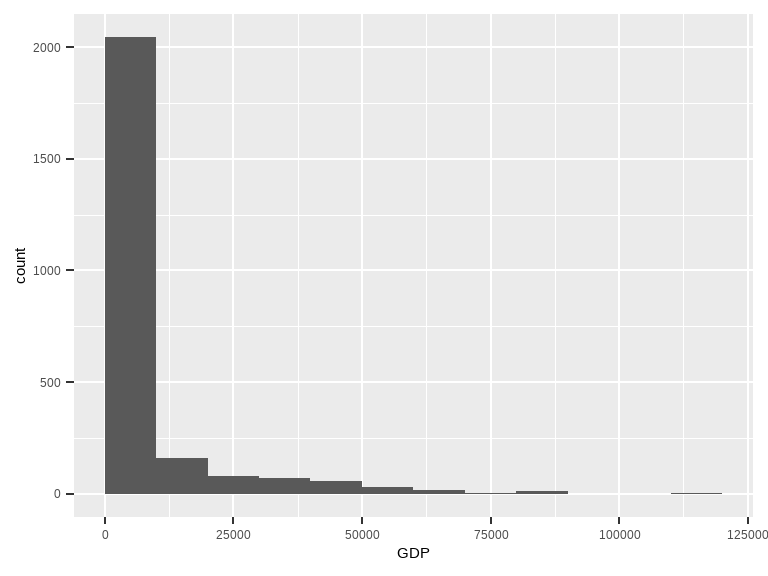

- Note that the following possible outlier values were detected: "61191.19", "61235.42", "61388.17", "61478.24", "61753.67", …, "89739.71", "113751.85", "114293.84", "115761.58", "119172.74" (26 values omitted).

## Population

| Feature | Result |
| --- | --- |
| Variable type | numeric |
| Number of missing obs. | 652 (22.19 %) |
| Number of unique values | 2278 |
| Median | 1386542 |
| 1st and 3rd quartiles | 195793.25; 7420359 |
| Min. and max. | 34; 1293859294 |

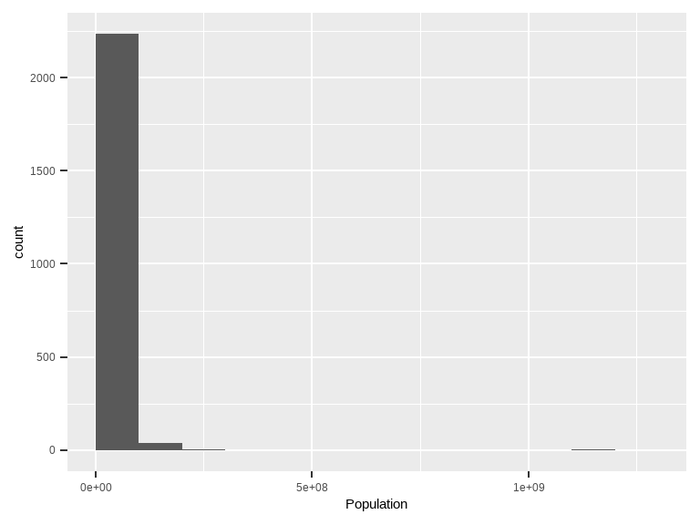

- Note that the following possible outlier values were detected: "111836346", "117318941", "119714696", "121427132", "122535969", …, "1126135777", "1144118674", "1161977719", "1179681239", "1293859294" (41 values omitted).

## thinness _1to19years

| Feature | Result |
| --- | --- |
| Variable type | numeric |
| Number of missing obs. | 34 (1.16 %) |
| Number of unique values | 200 |
| Median | 3.3 |
| 1st and 3rd quartiles | 1.6; 7.2 |
| Min. and max. | 0.1; 27.7 |

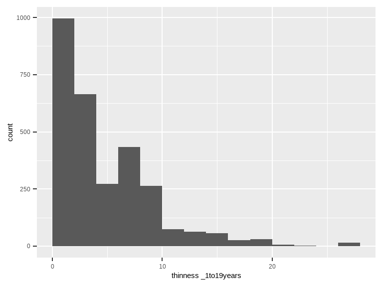

## thinness_5to9_years

| Feature | Result |
| --- | --- |
| Variable type | numeric |
| Number of missing obs. | 34 (1.16 %) |
| Number of unique values | 207 |
| Median | 3.3 |
| 1st and 3rd quartiles | 1.5; 7.2 |
| Min. and max. | 0.1; 28.6 |

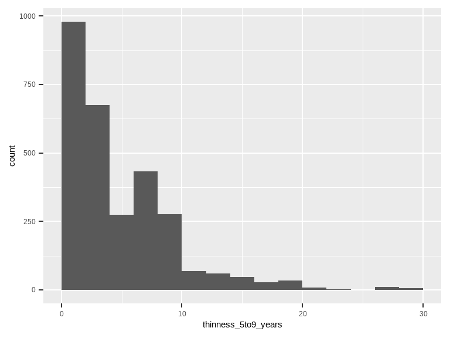

## Income composition of resources

| Feature | Result |
| --- | --- |
| Variable type | numeric |
| Number of missing obs. | 167 (5.68 %) |
| Number of unique values | 625 |
| Median | 0.68 |
| 1st and 3rd quartiles | 0.49; 0.78 |
| Min. and max. | 0; 0.95 |

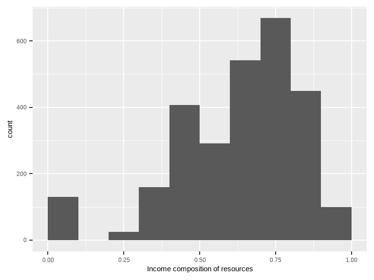

- Note that the following possible outlier values were detected: "0.94", "0.94", "0.94", "0.94", "0.94", "0.94", "0.94", "0.95".

## Schooling

| Feature | Result |
| --- | --- |
| Variable type | numeric |
| Number of missing obs. | 163 (5.55 %) |
| Number of unique values | 173 |
| Median | 12.3 |
| 1st and 3rd quartiles | 10.1; 14.3 |
| Min. and max. | 0; 20.7 |

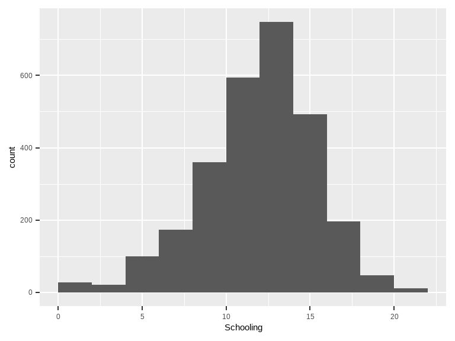

- Note that the following possible outlier values were detected: "0", "18.4", "18.5", "18.6", "18.7", …, "20.3", "20.4", "20.5", "20.6", "20.7" (10 values omitted).

Report generation information:

- Created by: Could not determine from system (username: `LENOVO`).
- Report creation time: Fri Apr 07 2023 22:20:26
- Report was run from directory: `D:/PROGRAMMING - LABS/Statistics-for-Business-Regression`
- dataMaid v1.4.1 [Pkg: 2021-10-08 from CRAN (R 4.2.3)]
- R version 4.2.2 (2022-10-31 ucrt).
- Platform: x86_64-w64-mingw32/x64 (64-bit)(Windows 10 x64 (build 22621)).
- Function call: `makeDataReport(data = df_2, output = "html")`